# Avaliação 1

Daniel Krügel

2023-04-17

# Introdução

Para este trabalho com data de entrega do dia 17/04/2023 foi utilizado como editor de texto a linguagem markdown e para criação de tabelas e a facilitação da exibição de alguns calculos a linguagem R. Tentarei ser o mais claro possível neste trabalho, porém caso seja necessário tenho as anotações feitas por mim durante a execução do trabalho que seram enviadas ao email ary.sabbag@ufpr.br (e-mail encontrado no website departamental) em formato de PDF.

# Resolução do problema para 2 jogadores

Dado que temos
$$X(t) = z_1 + z_2$$
onde X(t) equivale o que será pago pela banca e cada um dos Z o que cada jogador receberá após t jogadas.

É conhecido neste problema o quanto cada um receberá após a jogada de um dado, portanto todas as probabilidades de resultados serão derivadas da multiplicação ponto a ponto de cada uma das probabilidades, também conhecido como o Teorema de Faurier, teorema do qual o teorema de convolução é derivado.

Realizando as multiplicações teremos o seguinte dataframe:

| x numeric | P[X2 = x] character | P[X2 <= x] numeric |
| --- | --- | --- |
| 0 | 16/36 | 0.44000 |
| 1 | 8/36 | 0.66000 |
| 2 | 1/36 | 0.69000 |
| 6 | 8/36 | 0.91600 |
| 7 | 2/36 | 0.97200 |
| 12 | 1/36 | 1.00000 |

Considerando essa tabela de valores acumulados podemos dar uma olhada no gráfico de probabilidades acumulada:

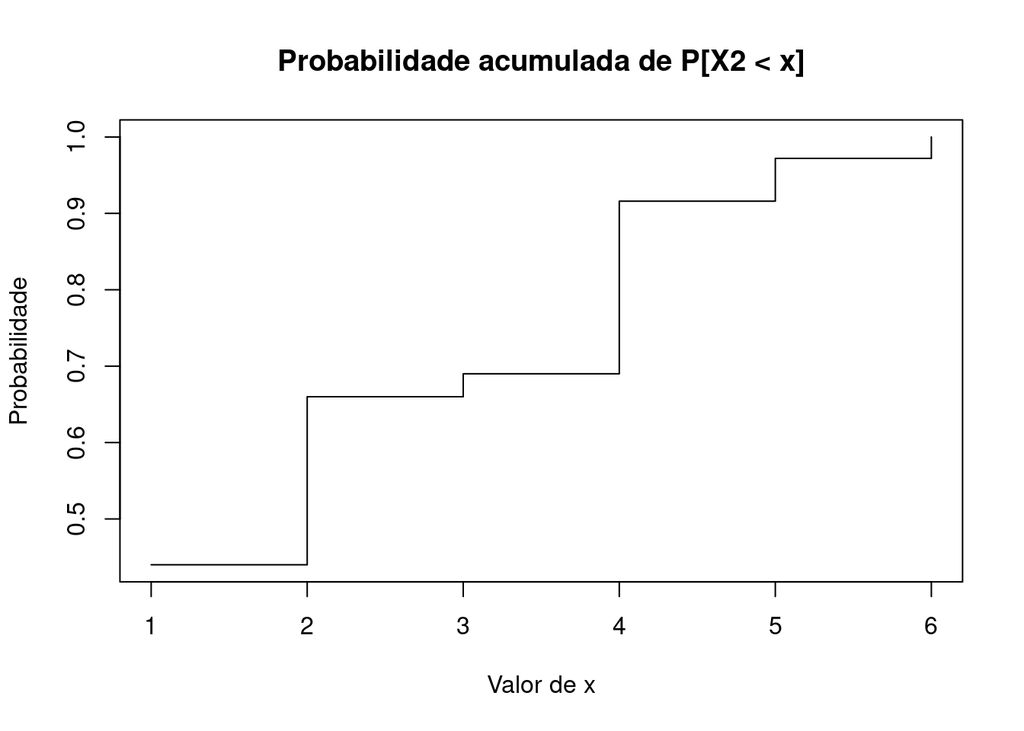

O Xc equivale ao preço pago pelos 2 jogadores para que a banca não quebre com probabilidade epsolon, portanto o Xc que nos dará uma chance aceitável da banca se manter aberta $1 - \epsilon$ é de 6 unidades monetárias, dando 3 unidades para cada jogador

# Esperança

Para calcularmos o valor esperado de pagamentos da banca, utilizaremos a fórmula dada em sala, que não passa do calculo do primeiro momento de uma distribuição discreta:

$$\sum\limits_{t=1}^{n}x_t*X(t)$$

Em código do R ficará:

```r
px2xV2 <- c(16/36,8/36,1/36,8/36,2/36,1/36)
Ex2 <- sum(df2$x * px2xV2)
Ex2
```

```
## [1] 2.333333
```

## Variancia

Para a variância utilizaremos o teorema:
$$Var(\mu) = E[\mu^2] - (E[\mu])^2$$

Ou seja a variância de uma variável aleatória é o segundo momento menos o quadrado do primeiro, portando utilizando o R para fazer este calculo e exibi-lô para o senhor fica:

```r
# Calculo da variância de x2
SegMomento2 <- sum((df2$x^2)*px2xV2)
SegMomento2
```

```
## [1] 15.05556
```

```r
Varx2 <- SegMomento2 - (Ex2^2)
Varx2
```

```
## [1] 9.611111
```

# Calculos para 3 jogadores

$$X(t) = Z_1 + Z_2 + Z_3$$

Aqui seguiremos a mesma lógica de como foi feito para 2 jogadores, como sabemos pelo teorema de convolução que a soma de 3 variáveis aleatórias recai novamente em uma soma de duas, neste caso será dada por:
$$f[z_3\otimes(z_1+z_2)]$$
No R isto será exibido pela seguinte tabela:

|  | 0 | 1 | 6 |
| --- | --- | --- | --- |
| 0 | 0.29629630 | 0.074074074 | 0.074074074 |
| 1 | 0.14814815 | 0.037037037 | 0.037037037 |
| 2 | 0.01851852 | 0.004629630 | 0.004629630 |
| 6 | 0.14814815 | 0.037037037 | 0.037037037 |
| 7 | 0.03703704 | 0.009259259 | 0.009259259 |
| 12 | 0.01851852 | 0.004629630 | 0.004629630 |

Para olharmos para a função de distribuição acumulada temos a seguinte tabela:

| x | P[X3 = x] | P[X3 = x] calculado | P[X3 <= x] |
| --- | --- | --- | --- |
| 0 | 64/216 | 0.29630 | 0.29620 |
| 1 | 48/216 | 0.22222 | 0.51850 |
| 2 | 12/216 | 0.05556 | 0.57400 |
| 3 | 1/216 | 0.00463 | 0.57860 |
| 6 | 48/216 | 0.22222 | 0.80000 |
| 7 | 24/216 | 0.11111 | 0.91000 |
| 8 | 3/216 | 0.01389 | 0.92000 |
| 12 | 12/216 | 0.05556 | 0.98140 |
| 13 | 3/216 | 0.01389 | 0.99500 |
| 18 | 1/216 | 0.00463 | 1.00000 |

Vamos dar uma olhada no gráfico da função distribuição acumulada de $X_3(t)$:

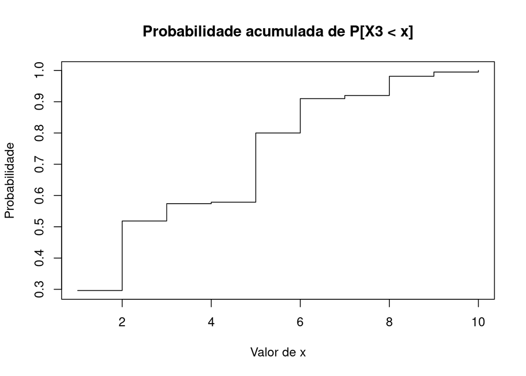

Seguindo a mesma lógica usada para 2 jogadores o Xc que me dará um valor de $P[x_c <= 1 - \epsilon]$ é aproximadamente 7. Dando um valor para cada jogador de aproximadamente 7/3 = 2,33

# Esperança

Como a quantidade média paga pela banca é a esperança de $X_3(t)$ utilizarei o R para fazer este calculo:

```r
Ex3 <- sum(df3V2$x * px3xV2)
Ex3
```

```
## [1] 3.5
```

## Variancia

Utilizarei o mesmo pensamento que da versão com 2 jogadores para o calculo de variancia de $X_3(t)$

```r
# Calculo da variância para 3 jogadores

SegMomento3 <- sum((df3V2$x^2)*px3xV2)
SegMomento3
```

```
## [1] 26.66667
```

```r
Varx3 <- SegMomento3 - (Ex3^2)
Varx3
```

```
## [1] 14.41667
```

# Calculando para 4 jogadores

## ! Atenção !

Como tive pouco tempo para me planejar para a realização deste trabalho, há um erro nas probabilidades de 4 jogadores, alguma das combinações de probabilidades foi deixada de lado, por conta disso os calculos estão incorretos e a acumulada não resulta em 1 quando somado todos os elementos da sigma algebra.

# Resolução

$$X_4(t) = z_1 + z_2 + z_3 + z_4$$
O caso de 4 jogadores, assim como o de 3 jogadores recai em uma soma de duas variáveis aleatórias, sendo elas $z_4$ e $(z_1 + z_2 + z_3)$ portanto o tma de faurier recai na seguinte equação:
$$f[z_4\otimes(z_1+z_2+z_3)]$$
A multiplicação ponto a ponto recai na seguinte tabela:

|  | 0 | 1 | 6 |
| --- | --- | --- | --- |
| 0 | 0.197530864 | 0.0493827160 | 0.0493827160 |
| 1 | 0.148148148 | 0.0370370370 | 0.0370370370 |
| 2 | 0.037037037 | 0.0092592593 | 0.0092592593 |
| 3 | 0.003086420 | 0.0007716049 | 0.0007716049 |
| 6 | 0.148148148 | 0.0370370370 | 0.0370370370 |
| 7 | 0.074074074 | 0.0185185185 | 0.0185185185 |
| 8 | 0.009259259 | 0.0023148148 | 0.0023148148 |
| 12 | 0.037037037 | 0.0092592593 | 0.0092592593 |
| 13 | 0.009259259 | 0.0023148148 | 0.0023148148 |
| 18 | 0.003086420 | 0.0007716049 | 0.0007716049 |

Fazendo a acumulada da sigma algebra teremos a seguinte tabela:

| x | P[X4 = x] | P[X4 = x] calculado | P[X4 <= x] |
| --- | --- | --- | --- |
| 0 | 256/1296 | 0.19753 | 0.19750 |
| 1 | 256/1296 | 0.19753 | 0.39500 |
| 2 | 96/1296 | 0.07407 | 0.46910 |
| 3 | 16/1296 | 0.01235 | 0.48140 |
| 4 | 1/1296 | 0.00077 | 0.48220 |
| 6 | 256/1296 | 0.19753 | 0.67970 |
| 7 | 192/1296 | 0.14815 | 0.82790 |
| 8 | 48/1296 | 0.03704 | 0.86400 |
| 9 | 4/1296 | 0.00309 | 0.86800 |
| 12 | 96/1296 | 0.07407 | 0.94210 |
| 13 | 24/1296 | 0.01852 | 0.96050 |
| 14 | 3/1296 | 0.00231 | 0.96290 |
| 18 | 16/1296 | 0.01235 | 0.94520 |
| 19 | 1/1296 | 0.00077 | 0.97600 |
| 24 | 1/1296 | 0.00077 | 0.97670 |

Como comentado a cima, faltou alguma das combinações de probabilidade na hora de calcular a acumulada, por isso falta aproximadamente 3% para que a acumulada dê 1.

Porém seguirei com as questões mesmo sabendo deste erro para ter alguma entrega.

Utilizando a mesma lógica que as questôes anteriores o X crítico é de 12, com uma probabilidade de ruína de (1-0,94) 0.06, tendo como custo unitário para cada jogador algo em torno de 12/4 = 3 unidades monetárias.

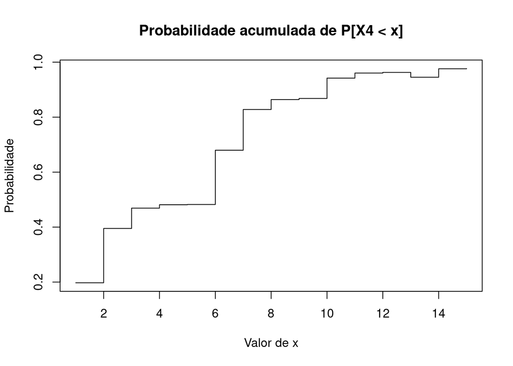

```r
plot(px4mx,
     main = "Probabilidade acumulada de P[X4 < x]",
     ylab = "Probabilidade",
     xlab = "Valor de x",
     type = "s")
```

# Esperança

A ideia de pagamento médio segue o mesmo que as anteriores, portanto:

```r
Ex4 <- sum(df4V2$x * px4xV2)
Ex4
```

```
## [1] 4.349537
```

# Variância

```r
SegMomento4 <- sum((df4V2$x^2)*px4xV2)
SegMomento4
```

```
## [1] 36.58102
```

```r
Varx4 <- SegMomento4 - (Ex4^2)
Varx4
```

```
## [1] 17.66255
```

# Para 3000 jogadores

Como temos um n muito grande, podemos utilizar o teorema central do limite para aproximar o resultado em uma normal média 0 e desvio padrão 1 Portanto teremos
$$S_n = z_1 + z_2 + z_3 +
... + z_n$$
Onde z1, z2, z3… zn são idependentes e identicamente distribuídas onde $E[z_i] = \mu$ e $var[z_i] = \sigma²$ podemos tirar que:
$$E[S_n] =
E[\sum\limits_{i=1}^{n}z_i]=\sum\limits_{i=1}^{n}E[z_i]=\sum\limits_{i=1}^{n}\mu=n\mu$$
$$Var[S_n] = Var[\sum\limits_{i=1}^{n}z_i] =
\sum\limits_{i=1}^{n}E[z_i] = \sum\limits_{i=1}^{n}\sigma^2 =
n\sigma^2$$
Portanto:
$$S_n \approx
N(n*\mu,n*\sigma)$$

No R para um jogador:

```r
x <- c(0,1,6)
prob <- c(4/6,1/6,1/6)

espX <- sum(x*prob)
segMomentoX <- sum((x^2) * prob)

varianciaX <- segMomentoX - espX^2
as_flextable(data.frame("Esperança" = espX, "2Momento" = segMomentoX, "Variancia" = varianciaX))
```

| Esperança numeric | 1.166667 |
| --- | --- |
| X2Momento numeric | 6.166667 |
| Variancia numeric | 4.805556 |

```r
n <- 3000
exp3000 <- espX * n
var3000 <- varianciaX * n
dp3000 <- sqrt(var3000)
```